# 🛒 Consumer Shopping Behaviour Analysis — 2026

### A Full-Stack Data Science Portfolio Project

**Dataset:** Consumer Shopping Trends 2026 | **Features:** Demographic · Digital · Behavioural · Spending  
**Stack:** `Python` · `Pandas` · `Scikit-learn` · `XGBoost` · `LightGBM` · `SHAP` · `Plotly` · `Matplotlib` · `Seaborn`

## 📌 Analytical Framework

| Phase | Section | Focus |
| --- | --- | --- |
| **Setup** | §0 | Libraries · Design system · Feature engineering |
| **EDA** | §1 – §7 | KPIs · Demographics · Digital · Spending · Preferences · Psychology |
| **Statistical** | §8 – §9 | Correlation · Sankey · Sunburst · Parallel Coordinates |
| **Unsupervised ML** | §10 | K-Means Clustering · PCA · Segment profiling |
| **Supervised ML** | §11 – §13 | Classification · Regression · XGBoost · SHAP · Hyperparameter Tuning |
| **Findings** | §14 | Key insights · Strategic recommendations |

> *Skills demonstrated: Exploratory Data Analysis · Feature Engineering · Statistical Visualisation · Clustering · Multi-class Classification · Regression · Model Explainability (SHAP) · Dashboard Design*

## ⚙️ Section 0 — Project Setup & Design System

**What this covers:**  
Environment configuration, library imports, and a unified dark-theme design system (custom Matplotlib `rcParams` + Plotly template) applied consistently across all 14 sections.

**Skills:** `Environment management` · `Custom theme engineering` · `Plotly template API` · `Matplotlib rcParams`

```python
%load_ext autoreload
%autoreload 2

import sys
sys.path.append(r"d:/project")   # if your module is outside notebook folder
```

```
The autoreload extension is already loaded. To reload it, use:
  %reload_ext autoreload
```

```python
import fix_shap
```

```
SHAP cell overwritten at index 48.
Causal cell overwritten at index 51.
Done.
```

```python
# Install required packages using %pip for notebook compatibility
%pip install -q plotly kaleido shap
import warnings; warnings.filterwarnings('ignore')
import numpy as np
import pandas as pd
import matplotlib.pyplot as plt
import matplotlib.ticker as mtick
import plotly.express as px
import plotly.graph_objects as go
import seaborn as sns
from plotly.subplots import make_subplots
from sklearn.model_selection import train_test_split
from scipy import stats
from math import pi

from sklearn.preprocessing import LabelEncoder, StandardScaler
from sklearn.linear_model import LogisticRegression
from sklearn.tree import DecisionTreeClassifier
from sklearn.ensemble import RandomForestClassifier, GradientBoostingClassifier, GradientBoostingRegressor

from sklearn.metrics import (classification_report, confusion_matrix, ConfusionMatrixDisplay,
                             accuracy_score, roc_auc_score, roc_curve, mean_absolute_error,
                             mean_squared_error, r2_score)
from sklearn.cluster import KMeans
from sklearn.decomposition import PCA
from sklearn.pipeline import Pipeline
```

```python
# ── DESIGN TOKENS ──────────────────────────────────────────────────────────────
BG      = '#0a0a14'   # deep navy-black
AX_BG   = '#12122a'   # dark indigo panel
CARD_BG = '#1a1a3a'   # card surface
TEXT_C  = '#e8ecf8'   # cool white
MUTED   = '#7a84a0'   # secondary labels / tick text
GRID_C  = '#1f1f42'   # subtle grid lines

# Semantic palette  (Online=blue, Store=coral, Hybrid=mint, then accents)
PAL = [
    '#4da6ff',  # 0 Online / primary blue
    '#ff6b6b',  # 1 Store  / coral red
    '#4ecb8d',  # 2 Hybrid / mint green
    '#ffd166',  # 3 accent yellow
    '#c77dff',  # 4 violet
    '#ff9f43',  # 5 warm orange
    '#2dd4bf',  # 6 teal
    '#f28b82',  # 7 salmon
    '#a8d8ea',  # 8 sky blue
    '#b5ead7',  # 9 sage
]
PREF_COLORS = {'Online': PAL[0], 'Store': PAL[1], 'Hybrid': PAL[2]}

# ── MATPLOTLIB GLOBAL THEME ─────────────────────────────────────────────────────
import matplotlib as mpl
mpl.rcParams.update({
    'figure.facecolor':   BG,
    'axes.facecolor':     AX_BG,
    'axes.edgecolor':     GRID_C,
    'axes.labelcolor':    TEXT_C,
    'axes.titlesize':     12,
    'axes.titleweight':   'bold',
    'axes.titlepad':      10,
    'xtick.color':        MUTED,  'xtick.labelsize': 9,
    'ytick.color':        MUTED,  'ytick.labelsize': 9,
    'text.color':         TEXT_C,
    'grid.color':         GRID_C, 'grid.linestyle': '--', 'grid.linewidth': 0.6,
    'axes.spines.top':    False,  'axes.spines.right': False,
    'axes.spines.left':   True,   'axes.spines.bottom': True,
    'font.family':        'DejaVu Sans',
    'legend.facecolor':   CARD_BG, 'legend.edgecolor': GRID_C,
    'legend.fontsize':    9,       'legend.framealpha': 0.8,
    'figure.dpi':         110,
})

# ── PLOTLY CUSTOM TEMPLATE ──────────────────────────────────────────────────────
import plotly.io as pio
import plotly.graph_objects as go

pio.templates['consumer'] = go.layout.Template(layout=go.Layout(
    paper_bgcolor=BG, plot_bgcolor=AX_BG,
    font=dict(family='Inter, Arial, sans-serif', color=TEXT_C, size=12),
    title_font=dict(size=15, color=TEXT_C),
    colorway=PAL,
    xaxis=dict(gridcolor=GRID_C, gridwidth=0.5, showline=True, linecolor=GRID_C,
               tickfont=dict(color=MUTED, size=10), zerolinecolor=GRID_C),
    yaxis=dict(gridcolor=GRID_C, gridwidth=0.5, showline=True, linecolor=GRID_C,
               tickfont=dict(color=MUTED, size=10), zerolinecolor=GRID_C),
    legend=dict(bgcolor='rgba(26,26,58,0.85)', bordercolor=GRID_C,
                borderwidth=1, font=dict(color=TEXT_C, size=10)),
    hoverlabel=dict(bgcolor=CARD_BG, font_color=TEXT_C, bordercolor=GRID_C),
    margin=dict(l=65, r=35, t=65, b=55),
))
pio.templates.default = 'consumer'
PT = 'consumer'

print('Design system ready — BG, AX_BG, PAL, PREF_COLORS, PT all available.')
```

```
Design system ready — BG, AX_BG, PAL, PREF_COLORS, PT all available.
```

## 📦 Section 1 — Data Overview & Feature Engineering

**What this covers:**  
Loading the raw dataset and constructing derived features that unlock richer analytical signals downstream.

**Skills:** `Pandas` · `Feature engineering` · `Domain-driven variable construction`

[output not shown]

```python
df = pd.read_csv('Consumer_Shopping_Trends_2026.csv')
print('✅ Dataset loaded!')

# ---------feature engineering---------
df['total_spend'] = df['avg_online_spend'] + df['avg_store_spend']
df['online_spend_pct'] = df['avg_online_spend'] / df['total_spend'].replace(0, np.nan) * 100
df['digital_score'] = (df['daily_internet_hours'] + df['social_media_hours'] + df['tech_savvy_score']
                        + df['online_payment_trust_score']) / 4
df['age_group'] = pd.cut(df['age'], bins=[18, 25, 35, 50, 65, 100], labels=['18-25', '26-35', '36-50', '51-65', '65+'])
df['income_group'] = pd.cut(df['monthly_income'], bins=[0, 30000, 60000, 100000, 150000, np.inf],
                           labels=['<30k', '30-60k', '60-100k', '100-150k', '150k+'])

print( f'\n ✅ Loaded! Shape: {df.shape}' )
print( f'Shopping Preferences: {df.columns.tolist()}' )
print( f'City tiers          : {df.city_tier.value_counts().to_dict()}' )
print(f'Gender split       : {df.gender.value_counts().to_dict()}')
df.head()
```

```
✅ Dataset loaded!

 ✅ Loaded! Shape: (11789, 30)
Shopping Preferences: ['age', 'monthly_income', 'daily_internet_hours', 'smartphone_usage_years', 'social_media_hours', 'online_payment_trust_score', 'tech_savvy_score', 'monthly_online_orders', 'monthly_store_visits', 'avg_online_spend', 'avg_store_spend', 'discount_sensitivity', 'return_frequency'…
City tiers          : {'Tier 1': 3982, 'Tier 3': 3949, 'Tier 2': 3858}
Gender split       : {'Male': 3966, 'Female': 3931, 'Other': 3892}
```

|  | age | monthly_income | daily_internet_hours | smartphone_usage_years | social_media_hours | online_payment_trust_score | tech_savvy_score | monthly_online_orders | monthly_store_visits | avg_online_spend | ... | environmental_awareness | time_pressure_level | gender | city_tier | shopping_preference | total_spend | online_spend_pct | digital_score | age_group | income_group |
| --- | --- | --- | --- | --- | --- | --- | --- | --- | --- | --- | --- | --- | --- | --- | --- | --- | --- | --- | --- | --- | --- |
| 0 | 56 | 221111 | 6.5 | 12 | 0.7 | 1 | 6 | 16 | 16 | 28551 | ... | 5 | 2 | Other | Tier 3 | Store | 172643 | 16.537595 | 3.550 | 51-65 | 150k+ |
| 1 | 69 | 96029 | 8.2 | 13 | 2.7 | 6 | 9 | 14 | 1 | 124056 | ... | 1 | 7 | Male | Tier 3 | Hybrid | 152477 | 81.360467 | 6.475 | 65+ | 60-100k |
| 2 | 46 | 19055 | 6.4 | 4 | 2.1 | 10 | 8 | 2 | 0 | 81939 | ... | 3 | 3 | Female | Tier 3 | Store | 210168 | 38.987382 | 6.625 | 36-50 | <30k |
| 3 | 32 | 53170 | 6.4 | 11 | 0.7 | 2 | 10 | 20 | 3 | 35901 | ... | 6 | 6 | Female | Tier 1 | Store | 170551 | 21.050009 | 4.775 | 26-35 | 30-60k |
| 4 | 60 | 244016 | 6.0 | 5 | 0.7 | 2 | 5 | 18 | 16 | 131971 | ... | 1 | 6 | Male | Tier 3 | Store | 166093 | 79.456088 | 3.425 | 51-65 | 150k+ |

5 rows × 30 columns

## 📊 Section 2 — KPI Dashboard

**What this covers:**  
Executive-level summary cards and distribution charts delivering an at-a-glance view of the consumer base across shopping preferences, city tiers, and spend channels.

**Skills:** `KPI card design` · `Multi-panel Matplotlib` · `Interactive Plotly figures` · `Custom colour theming`

**📌 What to observe:** Channel mix (Online vs Store vs Hybrid), city-tier distribution, and whether avg monthly orders align with avg total spend — these set the context for every downstream section.

```python
kpi = {'Total Consumers': f'{len(df)}',
       'Avg Monthly Orders': f' ${df.monthly_online_orders.mean():,.0f}',
       'Avg Total Spend': f' ${df.total_spend.mean():,.0f}',
       'Avg Digital Score': f' {df.digital_score.mean():,.2f}',
       'Avg Online Spend %': f' {df.online_spend_pct.mean():.2f}%',
       'Avg Store Spend': f' ${df.avg_store_spend.mean():,.0f}',
       'Avg Online Spend': f' ${df.avg_online_spend.mean():,.0f}',
       'Avg Store Visits/Month': f' {df.monthly_store_visits.mean():.1f}',
       'Hybrid Shoppers %': f' {(df.shopping_preference == "Hybrid").mean() * 100:.2f}%',
       'Online Shoppers %': f' {(df.shopping_preference == "Online").mean() * 100:.2f}%',
       'Avg Brand Loyalty Score': f' {df.brand_loyalty_score.mean():.2f}/10',
       'Avg Tech Savvy Score': f' {df.tech_savvy_score.mean():.2f}/10'
       }

print('📊 Key Performance Indicators:')
print('\n'.join([f' {k:28s} : {v}' for k, v in kpi.items()]))
# for key, value in kpi.items():
#     print(f'{key}: {value}')

# print('\n✅ KPIs calculated!')
```

```
📊 Key Performance Indicators:
 Total Consumers              : 11789
 Avg Monthly Orders           :  $25
 Avg Total Spend              :  $150,217
 Avg Digital Score            :  4.89
 Avg Online Spend %           :  49.60%
 Avg Store Spend              :  $75,662
 Avg Online Spend             :  $74,555
 Avg Store Visits/Month       :  9.5
 Hybrid Shoppers %            :  3.13%
 Online Shoppers %            :  9.98%
 Avg Brand Loyalty Score      :  5.53/10
 Avg Tech Savvy Score         :  5.53/10
```

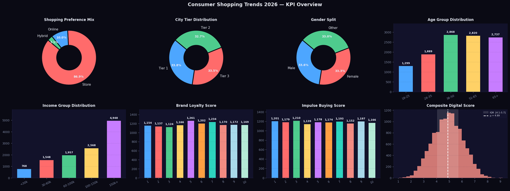

```python
fig, axes = plt.subplots(2, 4, figsize=(22, 8))
kpi_charts = [
    ('shopping_preference', 'Shopping Preference Mix', 'pie'),
    ('city_tier',           'City Tier Distribution',  'pie'),
    ('gender',              'Gender Split',             'pie'),
    ('age_group',           'Age Group Distribution',   'bar'),
    ('income_group',        'Income Group Distribution','bar'),
    ('brand_loyalty_score', 'Brand Loyalty Score',      'bar'),
    ('impulse_buying_score','Impulse Buying Score',     'bar'),
    ('digital_score',       'Composite Digital Score',  'hist'),
]

for ax, (col, title, kind) in zip(axes.flat, kpi_charts):
    if kind == 'pie':
        vals = df[col].value_counts()
        colors = [PREF_COLORS.get(v, PAL[i % len(PAL)]) for i, v in enumerate(vals.index)]
        _, texts, autotexts = ax.pie(
            vals.values, labels=vals.index, autopct='%1.1f%%',
            colors=colors, startangle=140,
            wedgeprops=dict(width=0.55, edgecolor=BG, linewidth=2.5),
            pctdistance=0.78, textprops={'color': TEXT_C, 'fontsize': 10},
        )
        for at in autotexts:
            at.set_fontsize(9); at.set_fontweight('bold')

    elif kind == 'bar':
        vals = df[col].value_counts().sort_index()
        bars = ax.bar(vals.index.astype(str), vals.values,
                      color=PAL[:len(vals)], edgecolor='none', width=0.62)
        for bar in bars:                          # value labels above bars
            h = bar.get_height()
            ax.text(bar.get_x() + bar.get_width() / 2,
                    h + vals.values.max() * 0.025,
                    f'{int(h):,}', ha='center', va='bottom',
                    fontsize=8, color=TEXT_C, fontweight='bold')
        ax.set_ylim(0, vals.values.max() * 1.20)
        ax.tick_params(axis='x', rotation=25)
        ax.grid(True, axis='y', alpha=0.2)

    else:                                         # histogram
        idx = [c for c, _, _ in kpi_charts].index(col)
        color = PAL[idx % len(PAL)]
        ax.hist(df[col].dropna(), bins=28, color=color, edgecolor='none', alpha=0.85)
        q1, q3 = df[col].quantile(0.25), df[col].quantile(0.75)
        ax.axvspan(q1, q3, alpha=0.12, color='white',
                   label=f'IQR  [{q1:.1f}–{q3:.1f}]')
        ax.axvline(df[col].mean(), color='white', lw=1.8, ls='--',
                   label=f'μ = {df[col].mean():.2f}')
        ax.grid(True, axis='y', alpha=0.2)
        ax.legend(fontsize=7, framealpha=0.3)

    ax.set_title(title, fontsize=11, fontweight='bold', color=TEXT_C, pad=8)

fig.suptitle('Consumer Shopping Trends 2026 — KPI Overview',
             fontsize=15, fontweight='bold', color=TEXT_C, y=1.02)
plt.tight_layout()
plt.show()
```

```python
# ── PLOTLY KPI CARD PANEL ──────────────────────────────────────────────────────
def _hex_rgba(h, a=0.9):
    h = h.lstrip('#')
    r, g, b = int(h[0:2],16), int(h[2:4],16), int(h[4:6],16)
    return f'rgba({r},{g},{b},{a})'

kpi_data = [
    ('Total Consumers',    f'{len(df):,}',                            PAL[0]),
    ('Avg Total Spend',    f'${df.total_spend.mean():,.0f}',          PAL[3]),
    ('Avg Online Spend',   f'${df.avg_online_spend.mean():,.0f}',     PAL[0]),
    ('Avg Store Spend',    f'${df.avg_store_spend.mean():,.0f}',      PAL[1]),
    ('Online Shoppers',    f'{(df.shopping_preference=="Online").mean()*100:.1f}%',  PAL[0]),
    ('Hybrid Shoppers',    f'{(df.shopping_preference=="Hybrid").mean()*100:.1f}%', PAL[2]),
    ('Avg Digital Score',  f'{df.digital_score.mean():.2f} / 10',     PAL[4]),
    ('Avg Brand Loyalty',  f'{df.brand_loyalty_score.mean():.2f} / 10', PAL[3]),
    ('Avg Monthly Orders', f'{df.monthly_online_orders.mean():.1f}',  PAL[5]),
    ('Avg Store Visits',   f'{df.monthly_store_visits.mean():.1f}/mo',PAL[1]),
    ('Avg Tech Savvy',     f'{df.tech_savvy_score.mean():.2f} / 10',  PAL[6]),
    ('Online Spend Share', f'{df.online_spend_pct.mean():.1f}%',      PAL[2]),
]
COLS, ROWS = 4, 3
fig = go.Figure()
for idx, (label, value, color) in enumerate(kpi_data):
    r_i, c_i = divmod(idx, COLS)
    x0 = c_i / COLS + 0.007;  x1 = (c_i + 1) / COLS - 0.007
    y0 = 1 - (r_i+1)/ROWS + 0.009;  y1 = 1 - r_i/ROWS - 0.009
    cx, cy = (x0+x1)/2, (y0+y1)/2
    # card background
    fig.add_shape(type='rect', xref='paper', yref='paper',
                  x0=x0, y0=y0, x1=x1, y1=y1,
                  fillcolor=CARD_BG, line=dict(color=color, width=1.4), layer='below')
    # top accent stripe
    stripe = (x1-x0) * 0.38
    fig.add_shape(type='rect', xref='paper', yref='paper',
                  x0=x0, y0=y1-0.008, x1=x0+stripe, y1=y1,
                  fillcolor=color, line=dict(width=0), layer='above')
    # metric value
    fig.add_annotation(xref='paper', yref='paper', x=cx, y=cy+0.047,
                       text=f'<b>{value}</b>', showarrow=False,
                       font=dict(size=18, color=color), xanchor='center')
    # label
    fig.add_annotation(xref='paper', yref='paper', x=cx, y=cy-0.05,
                       text=label, showarrow=False,
                       font=dict(size=10, color=MUTED), xanchor='center')

fig.update_layout(
    title='KPI Dashboard', height=370, showlegend=False,
    xaxis=dict(visible=False), yaxis=dict(visible=False),
    plot_bgcolor=BG, paper_bgcolor=BG,
    margin=dict(l=8, r=8, t=50, b=8),
)
fig.show()
```

## 👥 Section 3 — Demographic Profile

**What this covers:**  
Age distribution, gender split, and city-tier breakdown; plus how spend and activity patterns differ across age cohorts.

**Skills:** `Histogram analysis` · `Group aggregation` · `Grouped bar charts` · `Plotly subplots`

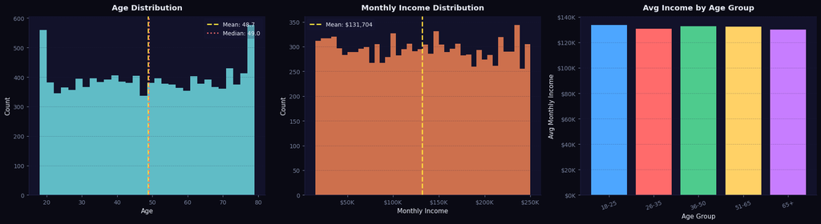

```python
fig, axes = plt.subplots(1, 3, figsize=(18, 5))

ax = axes[0]
ax.hist(df['age'], bins=30, color="#6fdbe3", edgecolor='none', alpha=0.85)
ax.axvline(df['age'].mean(), color='#ffd93d', lw=2, ls='--', label=f'Mean: {df.age.mean():.1f}')
ax.axvline(df['age'].median(), color='#ff6b6b', lw=2, ls=':', label=f'Median: {df.age.median():.1f}')
ax.set_title('Age Distribution', fontsize=12, fontweight='bold')
ax.set_xlabel('Age'); ax.set_ylabel('Count')
ax.legend(fontsize=9, framealpha=0.2); ax.grid(True, axis='y', alpha=0.3)

ax = axes[1]
ax.hist(df['monthly_income'], bins=40, color="#ef8254", edgecolor='none', alpha=0.85)
ax.axvline(df['monthly_income'].mean(), color='#ffd93d', lw=2, ls='--',
           label=f'Mean: ${df.monthly_income.mean():,.0f}')
ax.set_title('Monthly Income Distribution', fontsize=12, fontweight='bold')
ax.set_xlabel('Monthly Income'); ax.set_ylabel('Count')
ax.xaxis.set_major_formatter(mtick.FuncFormatter(lambda x,_: f'${x/1000:.0f}K')) #funcFormatter expects a function with two arguments:func(x, pos)
ax.legend(fontsize=9, framealpha=0.2); ax.grid(True, axis='y', alpha=0.3)

ax = axes[2]
age_income = df.groupby('age_group', observed=True)['monthly_income'].mean()
ax.bar(age_income.index.astype(str), age_income.values, color=PAL[:len(age_income)], edgecolor='none')
ax.set_title('Avg Income by Age Group', fontsize=12, fontweight='bold')
ax.set_xlabel('Age Group'); ax.set_ylabel('Avg Monthly Income')
ax.yaxis.set_major_formatter(mtick.FuncFormatter(lambda x,_: f'${x/1000:.0f}K'))
ax.tick_params(axis='x', rotation=20); ax.grid(True, axis='y', alpha=0.3)

plt.tight_layout(); plt.show()
```

```python
age_spend = df.groupby('age_group', observed=True).agg(
    Avg_Online=('avg_online_spend','mean'),
    Avg_Store=('avg_store_spend','mean'),
    Online_Orders=('monthly_online_orders','mean'),
    Store_Visits=('monthly_store_visits','mean')
).reset_index()

fig = make_subplots(rows=1, cols=2,
    subplot_titles=('Avg Spend by Age Group','Avg Activity by Age Group'))
for col, color in [('Avg_Online','#4d96ff'),('Avg_Store',"#f67438")]:
    fig.add_trace(go.Bar(name=col.replace('_',' '), x=age_spend['age_group'].astype(str),
                         y=age_spend[col], marker_color=color), row=1, col=1)
for col, color in [('Online_Orders','#6bcb77'),('Store_Visits','#ffd93d')]:
    fig.add_trace(go.Bar(name=col.replace('_',' '), x=age_spend['age_group'].astype(str),
                         y=age_spend[col], marker_color=color), row=1, col=2)
fig.update_layout(title='👤 Consumer Activity by Age Group', template=PT,
                  height=420, barmode='group', legend=dict(bgcolor='rgba(0,0,0,0.4)'))
fig.show()
```

## 💻 Section 4 — Digital Behaviour Analysis

**What this covers:**  
Internet hours, social media usage, smartphone tenure, tech-savvy score, and payment trust — aggregated by shopping preference to reveal the digital fingerprint of each consumer type.

**Skills:** `Composite index construction` · `Seaborn heatmap` · `Scatter regression` · `Multi-variate groupby`

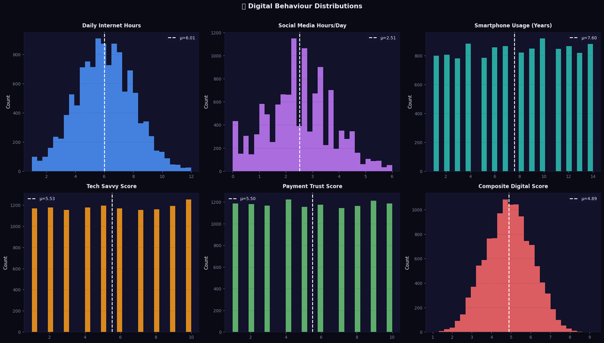

```python
digital_pairs = [
    ('daily_internet_hours','Daily Internet Hours','#4d96ff'),
    ('social_media_hours','Social Media Hours/Day','#c77dff'),
    ('smartphone_usage_years','Smartphone Usage (Years)','#2ec4b6'),
    ('tech_savvy_score','Tech Savvy Score','#ff9f1c'),
    ('online_payment_trust_score','Payment Trust Score','#6bcb77'),
    ('digital_score','Composite Digital Score','#ff6b6b'),
]
fig, axes = plt.subplots(2, 3, figsize=(18, 10))
for ax, (col, label, color) in zip(axes.flat, digital_pairs):
    ax.hist(df[col].dropna(), bins=30, color=color, edgecolor='none', alpha=0.85)
    ax.axvline(df[col].mean(), color='white', lw=1.8, ls='--', label=f'μ={df[col].mean():.2f}')
    ax.set_title(label, fontsize=11, fontweight='bold')
    ax.set_ylabel('Count'); ax.legend(fontsize=9, framealpha=0.2); ax.grid(True, axis='y', alpha=0.3)
plt.suptitle('💻 Digital Behaviour Distributions', fontsize=14, fontweight='bold', y=1.01)
plt.tight_layout(); plt.show()
```

```python
fig = px.scatter(
    df.sample(min(2000, len(df)), random_state=42),
    x='digital_score', y='avg_online_spend',
    color='shopping_preference', size='monthly_online_orders', #Bubble size encodes order volume
    hover_data=['age','gender','city_tier'],
    color_discrete_sequence=PAL, opacity=0.65,
    title='🔗 Digital Score vs Online Spend  (bubble = monthly orders)',
    labels={'digital_score':'Digital Score','avg_online_spend':'Avg Online Spend'},
    template=PT, height=480
)
fig.show()
```

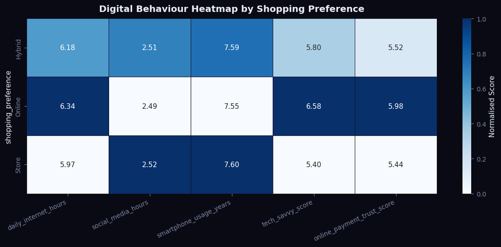

```python
dig_cols = ['daily_internet_hours','social_media_hours','smartphone_usage_years',
            'tech_savvy_score','online_payment_trust_score']
dig_by_pref = df.groupby('shopping_preference')[dig_cols].mean()
dig_norm = (dig_by_pref - dig_by_pref.min()) / (dig_by_pref.max() - dig_by_pref.min())

fig, ax = plt.subplots(figsize=(11, 5))
sns.heatmap(dig_norm, annot=dig_by_pref.round(2), fmt='.2f',
            cmap='Blues', linewidths=0.5, linecolor='#0d0d24',
            annot_kws={'size':10}, cbar_kws={'label':'Normalised Score'}, ax=ax) #Colorbar explains scale (0–1)
ax.set_title('Digital Behaviour Heatmap by Shopping Preference', fontsize=13, fontweight='bold', pad=10)
plt.xticks(rotation=25, ha='right'); plt.tight_layout(); plt.show()
```

## 💰 Section 5 — Spending Pattern Deep-Dive

**What this covers:**  
Spend distributions, channel-mix breakdowns by preference group, and income-vs-spend OLS regression faceted by city tier.

**Skills:** `Distribution analysis` · `OLS trendlines (statsmodels)` · `Plotly faceted scatter` · `make_subplots`

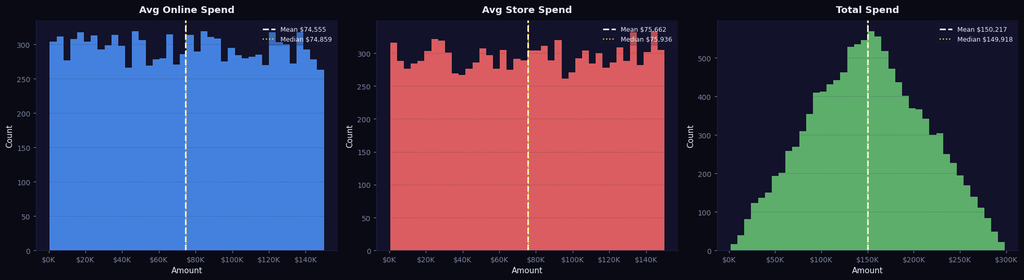

```python
fig, axes = plt.subplots(1, 3, figsize=(18, 5))
for ax, col, label, color in [
    (axes[0],'avg_online_spend','Avg Online Spend','#4d96ff'),
    (axes[1],'avg_store_spend','Avg Store Spend','#ff6b6b'),
    (axes[2],'total_spend','Total Spend','#6bcb77'),
]:
    ax.hist(df[col], bins=40, color=color, edgecolor='none', alpha=0.85)
    ax.axvline(df[col].mean(), color='white', lw=2, ls='--', label=f'Mean ${df[col].mean():,.0f}')
    ax.axvline(df[col].median(), color='#ffd93d', lw=1.5, ls=':', label=f'Median ${df[col].median():,.0f}')
    ax.set_title(label, fontsize=12, fontweight='bold')
    ax.set_xlabel('Amount'); ax.set_ylabel('Count')
    ax.xaxis.set_major_formatter(mtick.FuncFormatter(lambda x,_: f'${x/1000:.0f}K'))
    ax.legend(fontsize=8, framealpha=0.2); ax.grid(True, axis='y', alpha=0.3)
plt.tight_layout(); plt.show()
```

```python
fig = make_subplots(rows=1, cols=2,
    subplot_titles=('Online Spend % by Shopping Preference','Total Spend by City Tier'))
for i, pref in enumerate(df['shopping_preference'].unique()):
    data = df[df['shopping_preference']==pref]['online_spend_pct'].dropna()
    fig.add_trace(go.Violin(y=data, name=pref, box_visible=True, meanline_visible=True,
                            fillcolor=PAL[i], line_color='white', opacity=0.7), row=1, col=1)
city_spend = df.groupby('city_tier')['total_spend'].mean().reset_index()
fig.add_trace(go.Bar(x=city_spend['city_tier'], y=city_spend['total_spend'],
                     marker_color=PAL[:3], name='Avg Total Spend'), row=1, col=2)
fig.update_layout(title='💰 Spend Analysis by Preference & City Tier',
                  template=PT, height=460, showlegend=False)
fig.show()
```

```python
%pip install -q statsmodels
sample = df.sample(min(3000, len(df)), random_state=42)
fig = px.scatter(
    sample, x='monthly_income', y='total_spend',
    color='shopping_preference', facet_col='city_tier',
    color_discrete_sequence=PAL, opacity=0.55, trendline='ols',
    title='📈 Monthly Income vs Total Spend by City Tier',
    labels={'monthly_income':'Monthly Income','total_spend':'Total Spend'},
    template=PT, height=420
)
fig.show()
```

## 🏬 Section 6 — Shopping Preference Analysis

**What this covers:**  
Profiling each preference segment (Online / Store / Hybrid) by demographic, financial, and psychographic attributes — visualised as a radar (spider) chart for intuitive multi-dimensional comparison.

**Skills:** `GroupBy profiling` · `Radar/spider chart (Plotly)` · `Multi-dimensional comparison` · `Segment characterisation`

```python
pref_profile = df.groupby('shopping_preference').agg(
    Count=('age','count'),
    Avg_Age=('age','mean'),
    Avg_Income=('monthly_income','mean'),
    Avg_Online_Spend=('avg_online_spend','mean'),
    Avg_Store_Spend=('avg_store_spend','mean'),
    Avg_Online_Orders=('monthly_online_orders','mean'),
    Avg_Store_Visits=('monthly_store_visits','mean'),
    Avg_Brand_Loyalty=('brand_loyalty_score','mean'),
    Avg_Tech_Savvy=('tech_savvy_score','mean'),
    Avg_Impulse=('impulse_buying_score','mean'),
    Avg_Discount_Sensitivity=('discount_sensitivity','mean'),
    Avg_Environmental=('environmental_awareness','mean'),
).round(2).reset_index()
print('=== Shopping Preference Profile Comparison ===')
pref_profile.set_index('shopping_preference').T
```

```
=== Shopping Preference Profile Comparison ===
```

| shopping_preference | Hybrid | Online | Store |
| --- | --- | --- | --- |
| Count | 369.00 | 1176.00 | 10244.00 |
| Avg_Age | 47.87 | 49.79 | 48.64 |
| Avg_Income | 133405.19 | 130299.23 | 131804.31 |
| Avg_Online_Spend | 74304.44 | 76428.96 | 74348.82 |
| Avg_Store_Spend | 19030.38 | 11190.82 | 85102.73 |
| Avg_Online_Orders | 25.38 | 28.31 | 24.24 |
| Avg_Store_Visits | 9.15 | 8.28 | 9.63 |
| Avg_Brand_Loyalty | 5.67 | 5.52 | 5.53 |
| Avg_Tech_Savvy | 5.80 | 6.58 | 5.40 |
| Avg_Impulse | 5.69 | 5.48 | 5.48 |
| Avg_Discount_Sensitivity | 5.53 | 5.42 | 5.51 |
| Avg_Environmental | 5.49 | 5.32 | 5.46 |

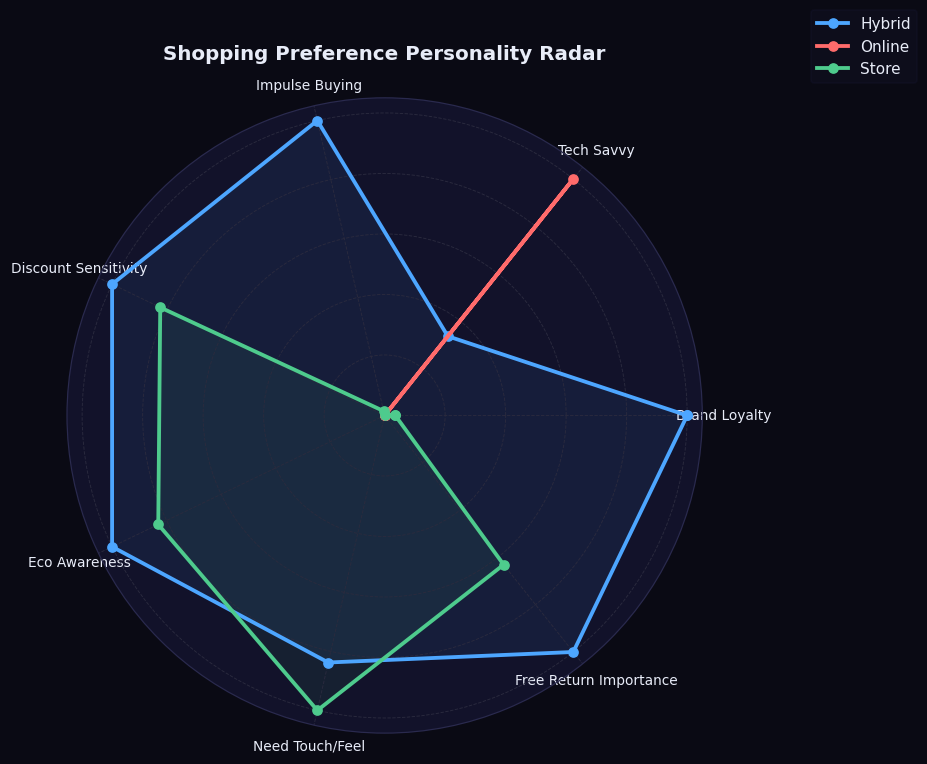

```python
radar_cols = ['brand_loyalty_score','tech_savvy_score','impulse_buying_score',
              'discount_sensitivity','environmental_awareness',
              'need_touch_feel_score','free_return_importance']
radar_labels = ['Brand Loyalty','Tech Savvy','Impulse Buying','Discount Sensitivity',
                'Eco Awareness','Need Touch/Feel','Free Return Importance']

pref_radar = df.groupby('shopping_preference')[radar_cols].mean()
pref_radar_n = (pref_radar - pref_radar.min()) / (pref_radar.max() - pref_radar.min())

N = len(radar_cols)
angles = [n/float(N)*2*pi for n in range(N)] + [0] #add starting angle

fig, ax = plt.subplots(figsize=(9, 7), subplot_kw=dict(polar=True)) #converts the axis into polar coordinates
ax.set_facecolor(AX_BG); fig.patch.set_facecolor(BG)

for i, pref in enumerate(pref_radar_n.index.tolist()): #each group, i is the index for color
    vals = pref_radar_n.loc[pref].tolist() + [pref_radar_n.loc[pref].tolist()[0]]  #vals = row + [row[0]] -->angles = [0, 1.25, 2.51, 3.77, 5.03, 0]
    ax.plot(angles, vals, 'o-', lw=2.5, color=PAL[i], label=pref)
    ax.fill(angles, vals, alpha=0.08, color=PAL[i])

ax.set_xticks(angles[:-1]) #angles includes the extra closing point; angles[:-1] removes the duplicate last angle
ax.set_xticklabels(radar_labels, color=TEXT_C, fontsize=9)
ax.set_yticklabels([])
ax.set_title('Shopping Preference Personality Radar', fontsize=13, fontweight='bold', color=TEXT_C, pad=25)
ax.legend(loc='upper right', bbox_to_anchor=(1.35, 1.15), framealpha=0.2, fontsize=10)
ax.spines['polar'].set_color('#2a2a4e'); ax.grid(color='#2a2a3e')
plt.tight_layout(); plt.show()
```

## 🧠 Section 7 — Psychological & Behavioural Scores

**Skills:** `Box plots` · `Violin plots` · `Plotly grouped charts` · `Behavioural analytics`

**📌 Key insight:** Tier-1 city residents show significantly higher environmental awareness and lower impulse-buying scores vs Tier-3 — premium sustainability messaging resonates in metro markets; value promotions work better in smaller cities.

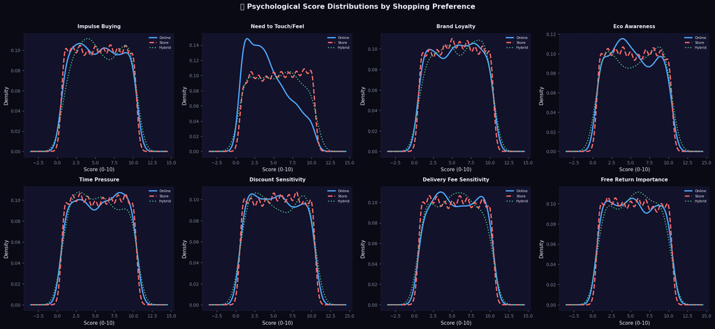

```python
score_cols = [
    ('impulse_buying_score','Impulse Buying','#ff6b6b'),
    ('need_touch_feel_score','Need to Touch/Feel','#ffd93d'),
    ('brand_loyalty_score','Brand Loyalty','#6bcb77'),
    ('environmental_awareness','Eco Awareness','#4d96ff'),
    ('time_pressure_level','Time Pressure','#c77dff'),
    ('discount_sensitivity','Discount Sensitivity','#ff9f1c'),
    ('delivery_fee_sensitivity','Delivery Fee Sensitivity','#2ec4b6'),
    ('free_return_importance','Free Return Importance','#e63946'),
]
fig, axes = plt.subplots(2, 4, figsize=(20, 9))
for ax, (col, label, color) in zip(axes.flat, score_cols): #iterate through axes and score columns simultaneously
    for pref, lw, ls in zip(['Online','Store','Hybrid'],[2.5,2.5,2],['-','--',':']): #pref group
        sub = df[df['shopping_preference']==pref][col].dropna()
        if len(sub) > 10:
            sub.plot.kde(ax=ax, label=pref,
                         color=PAL[['Online','Store','Hybrid'].index(pref)],
                         lw=lw, linestyle=ls)
    ax.set_title(label, fontsize=10, fontweight='bold')
    ax.set_xlabel('Score (0-10)'); ax.set_ylabel('Density')
    ax.legend(fontsize=7, framealpha=0.2); ax.grid(True, alpha=0.25)
plt.suptitle('🧠 Psychological Score Distributions by Shopping Preference',
             fontsize=14, fontweight='bold', y=1.01)
plt.tight_layout(); plt.show()
```

```python
melt_cols = ['brand_loyalty_score','impulse_buying_score',
             'environmental_awareness','discount_sensitivity']
melt_df = df[melt_cols + ['city_tier']].melt(id_vars='city_tier',
    var_name='Score_Type', value_name='Score')
fig = px.box(
    melt_df, x='Score_Type', y='Score', color='city_tier',
    color_discrete_sequence=PAL,
    title='📦 Key Behavioural Scores by City Tier',
    labels={'Score_Type':'Score','Score':'Score (0-10)'},
    template=PT, height=460
)
fig.show()
```

## 📐 Section 8 — Correlation & Feature Relationships

**What this covers:**  
A lower-triangle correlation heatmap across all numeric features, plus a pair-plot matrix on key spend and behaviour variables.

**Skills:** `Correlation matrix` · `Seaborn heatmap` · `Pair-plot matrix` · `Collinearity detection`

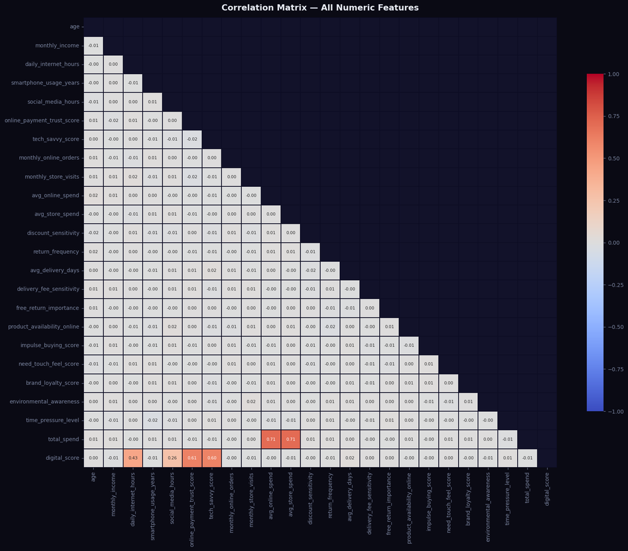

```python
num = df.select_dtypes(include=np.number).drop(columns=['online_spend_pct'], errors='ignore')
corr = num.corr()

fig, ax = plt.subplots(figsize=(16, 13))
mask = np.triu(np.ones_like(corr, dtype=bool))
sns.heatmap(corr, mask=mask, annot=True, fmt='.2f',
            cmap='coolwarm', center=0, vmin=-1, vmax=1,
            linewidths=0.3, linecolor='#0d0d24',
            annot_kws={'size':7}, cbar_kws={'shrink':0.75}, ax=ax)
ax.set_title('Correlation Matrix — All Numeric Features', fontsize=14, fontweight='bold', pad=12)
plt.tight_layout(); plt.show()
```

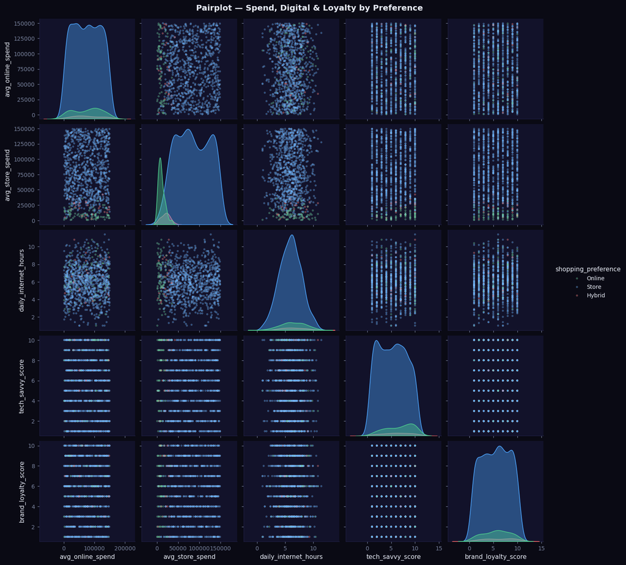

```python
pair_cols = ['avg_online_spend','avg_store_spend','daily_internet_hours',
             'tech_savvy_score','brand_loyalty_score','shopping_preference']
sample_p = df[pair_cols].sample(min(1000, len(df)), random_state=42)
pal_dict = dict(zip(df['shopping_preference'].unique(), PAL[:3]))
g = sns.pairplot(sample_p, hue='shopping_preference', palette=pal_dict,
                 diag_kind='kde', plot_kws={'alpha':0.4,'s':8},
                 diag_kws={'fill':True,'alpha':0.4})
g.figure.suptitle('Pairplot — Spend, Digital & Loyalty by Preference',
                   y=1.01, fontsize=13, fontweight='bold', color=TEXT_C)
g.figure.set_facecolor(BG)
for a in g.axes.flatten(): a.set_facecolor(AX_BG)
plt.show()
```

## 🗺️ Section 9 — Advanced Visualisations

**What this covers:**  
Three high-information-density interactive Plotly charts:

- **Sankey diagram** — Consumer flow: City Tier → Shopping Preference → Gender
- **Sunburst chart** — Hierarchical spend: City Tier → Preference → Age Group
- **Parallel Coordinates** — Multi-dimensional profile comparison across all preference groups

**Skills:** `Sankey flow diagrams` · `Sunburst hierarchical charts` · `Parallel coordinates` · `Plotly graph_objects`

```python
# ── SANKEY: Consumer Flow  City Tier → Shopping Preference → Gender ────────────
def _hex_rgba(h, a=0.35):
    h = h.lstrip('#'); r,g,b = int(h[:2],16),int(h[2:4],16),int(h[4:],16)
    return f'rgba({r},{g},{b},{a})'

san = df.groupby(['city_tier','shopping_preference','gender']).size().reset_index(name='n')

tiers  = df['city_tier'].unique().tolist()
prefs  = df['shopping_preference'].unique().tolist()
gends  = df['gender'].unique().tolist()
nodes  = tiers + prefs + gends
ni     = {n: i for i, n in enumerate(nodes)}

node_colors = (
    [_hex_rgba(PAL[5], 0.9)] * len(tiers) +
    [_hex_rgba(PREF_COLORS.get(p, PAL[0]), 0.9) for p in prefs] +
    [_hex_rgba(PAL[7], 0.9), _hex_rgba(PAL[8], 0.9)]
)

src, tgt, val, lc = [], [], [], []
for _, row in san.iterrows():
    src.append(ni[row['city_tier']]);  tgt.append(ni[row['shopping_preference']])
    val.append(row['n']);              lc.append(_hex_rgba(PREF_COLORS.get(row['shopping_preference'], PAL[0])))

san2 = df.groupby(['shopping_preference','gender']).size().reset_index(name='n')
for _, row in san2.iterrows():
    src.append(ni[row['shopping_preference']]); tgt.append(ni[row['gender']])
    val.append(row['n']);  lc.append(_hex_rgba(PREF_COLORS.get(row['shopping_preference'], PAL[0])))

fig = go.Figure(go.Sankey(
    node=dict(pad=18, thickness=18,
              line=dict(color=GRID_C, width=0.5),
              label=nodes, color=node_colors,
              hovertemplate='%{label}: %{value:,}<extra></extra>'),
    link=dict(source=src, target=tgt, value=val, color=lc),
))
fig.update_layout(
    title='Consumer Flow: City Tier → Shopping Preference → Gender',
    height=480, font=dict(color=TEXT_C, size=11),
    paper_bgcolor=BG, plot_bgcolor=BG,
)
fig.show()
```

```python
# ── SUNBURST: Total Spend  City Tier → Preference → Age Group ──────────────────
# Remove rows with missing or empty values in the path columns
df_sunburst = df.dropna(subset=['city_tier', 'shopping_preference', 'age_group'])
df_sunburst = df_sunburst[(df_sunburst['city_tier'] != '') & (df_sunburst['shopping_preference'] != '') & (df_sunburst['age_group'] != '')]
fig = px.sunburst(
    df_sunburst,
    path=['city_tier', 'shopping_preference', 'age_group'],
    values='total_spend',
    color='shopping_preference',
    color_discrete_map=PREF_COLORS,
    title='Total Spend Breakdown: City Tier → Preference → Age Group',
    height=580,
 )
fig.update_traces(
    textinfo='label+percent entry',
    insidetextorientation='radial',
    hovertemplate='<b>%{label}</b><br>Spend: $%{value:,.0f}<br>Share: %{percentParent:.1%}<extra></extra>',
 )
fig.update_layout(paper_bgcolor=BG, font_color=TEXT_C, margin=dict(t=60, b=10))
fig.show()
```

```python
# ── PARALLEL COORDINATES: Multi-Dimensional Consumer Profile ────────────────────
pref_code = df['shopping_preference'].map({'Online': 0, 'Hybrid': 1, 'Store': 2})
pc_cols   = ['age','monthly_income','digital_score','avg_online_spend',
             'avg_store_spend','brand_loyalty_score','impulse_buying_score',
             'discount_sensitivity']
pc_df = df[pc_cols].assign(pref_code=pref_code)

fig = go.Figure(go.Parcoords(
    line=dict(
        color=pc_df['pref_code'],
        colorscale=[[0, PAL[0]], [0.5, PAL[2]], [1, PAL[1]]],
        showscale=True,
        colorbar=dict(title='Preference', tickvals=[0,1,2],
                      ticktext=['Online','Hybrid','Store'],
                      tickfont=dict(color=TEXT_C),
                      bgcolor=CARD_BG),  # Removed titlefont, which is invalid
    ),
    dimensions=[
        dict(label=c.replace('_',' ').title(), values=pc_df[c],
             range=[pc_df[c].quantile(0.01), pc_df[c].quantile(0.99)])
        for c in pc_cols
    ],
    unselected=dict(line=dict(opacity=0.04)),
) )
fig.update_layout(
    title='Parallel Coordinates — Multi-Dimensional Consumer Profile',
    height=510, paper_bgcolor=BG, plot_bgcolor=AX_BG,
    font=dict(color=TEXT_C, size=10),
)
fig.show()
```

## 🔵 Section 10 — Customer Segmentation (K-Means Clustering)

**What this covers:**  
Unsupervised segmentation into 4 consumer personas using K-Means on 13 standardised features, with PCA 2D scatter visualisation and normalised heatmap cluster profiling.

**Skills:** `K-Means clustering` · `StandardScaler` · `PCA dimensionality reduction` · `Cluster profiling` · `Seaborn heatmap`

[output not shown]

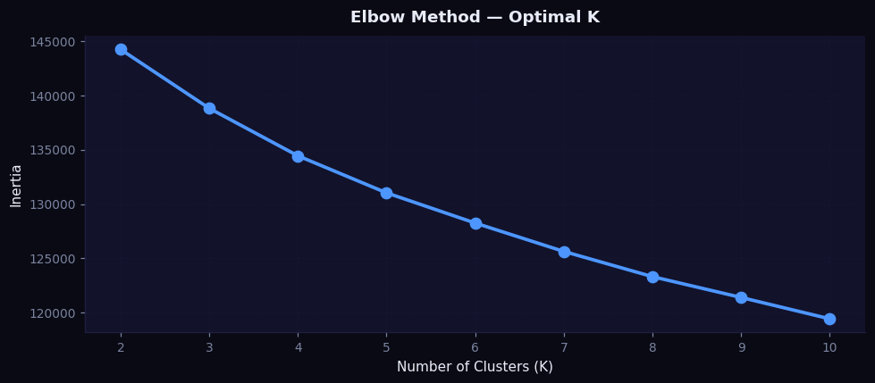

```python
cluster_feats = ['age','monthly_income','daily_internet_hours','monthly_online_orders',
                 'monthly_store_visits','avg_online_spend','avg_store_spend',
                 'brand_loyalty_score','impulse_buying_score','tech_savvy_score',
                 'discount_sensitivity','environmental_awareness','time_pressure_level']

X_cl = df[cluster_feats].dropna()
scaler = StandardScaler()
X_scaled = scaler.fit_transform(X_cl)

inertias = []
K_range = range(2, 11)
for k in K_range:
    km = KMeans(n_clusters=k, random_state=42, n_init=10)
    km.fit(X_scaled)
    inertias.append(km.inertia_)

fig, ax = plt.subplots(figsize=(9, 4))
ax.plot(K_range, inertias, 'o-', color='#4d96ff', lw=2.5, ms=8)
ax.set_title('Elbow Method — Optimal K', fontsize=12, fontweight='bold')
ax.set_xlabel('Number of Clusters (K)'); ax.set_ylabel('Inertia')
ax.grid(True, alpha=0.3)
plt.tight_layout(); plt.show()
```

```python
K = 4
km = KMeans(n_clusters=K, random_state=42, n_init=10)
df_cl = df.loc[X_cl.index].copy() #X_cl.index gives the indices of the rows that were used for clustering (i.e., those without missing values in the cluster features). By using df.loc[X_cl.index], we create a new DataFrame df_cl that contains only these rows, ensuring that the cluster labels we generate will align correctly with the original data.
df_cl['Cluster'] = km.fit_predict(X_scaled) #fit_predict() method computes cluster centers and predicts the cluster index for each sample in X_scaled, returning an array of cluster labels that we assign to the 'Cluster' column in df_cl.
df_cl['Cluster_Label'] = df_cl['Cluster'].map(
    {0:'Cluster 0',1:'Cluster 1',2:'Cluster 2',3:'Cluster 3'})

cluster_profile = df_cl.groupby('Cluster')[cluster_feats].mean().round(1)
print('=== Cluster Profiles (raw means) ===')
cluster_profile.T
```

```
=== Cluster Profiles (raw means) ===
```

| Cluster | 0 | 1 | 2 | 3 |
| --- | --- | --- | --- | --- |
| age | 49.7 | 49.2 | 47.9 | 48.2 |
| monthly_income | 134293.9 | 144620.6 | 127306.3 | 120612.9 |
| daily_internet_hours | 6.1 | 6.3 | 6.0 | 5.7 |
| monthly_online_orders | 24.0 | 25.1 | 25.3 | 24.2 |
| monthly_store_visits | 11.5 | 14.4 | 7.5 | 4.5 |
| avg_online_spend | 77429.4 | 75987.3 | 72667.9 | 72145.3 |
| avg_store_spend | 71799.6 | 74365.5 | 74845.9 | 81659.5 |
| brand_loyalty_score | 5.5 | 5.7 | 5.4 | 5.6 |
| impulse_buying_score | 3.3 | 7.7 | 3.2 | 7.8 |
| tech_savvy_score | 2.8 | 6.7 | 8.0 | 4.6 |
| discount_sensitivity | 5.7 | 5.2 | 5.5 | 5.6 |
| environmental_awareness | 5.8 | 5.7 | 5.2 | 5.1 |
| time_pressure_level | 5.3 | 5.2 | 5.9 | 5.6 |

```python
pca = PCA(n_components=2, random_state=42)
pcs = pca.fit_transform(X_scaled)
df_cl['PC1'] = pcs[:, 0]
df_cl['PC2'] = pcs[:, 1]

fig = px.scatter(
    df_cl.sample(min(3000, len(df_cl)), random_state=42),
    x='PC1', y='PC2', color='Cluster_Label', symbol='shopping_preference',
    color_discrete_sequence=PAL, opacity=0.55, size_max=8,
    title=f'🔵 K-Means Clusters (K={K}) — PCA 2D Projection',
    labels={'PC1':f'PC1 ({pca.explained_variance_ratio_[0]*100:.1f}% var)',
            'PC2':f'PC2 ({pca.explained_variance_ratio_[1]*100:.1f}% var)'},
    template=PT, height=520
)
fig.show()
```

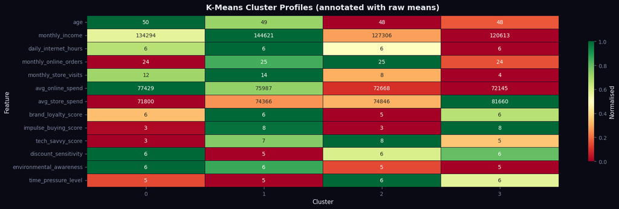

```python
cp_norm = (cluster_profile - cluster_profile.min()) / (cluster_profile.max() - cluster_profile.min())
fig, ax = plt.subplots(figsize=(16, 5))
sns.heatmap(cp_norm.T, annot=cluster_profile.T.round(0), fmt='.0f',  #cp_norm: row is cluster, column is feature; so need to transpose to have features on y-axis and clusters on x-axis. annot=cluster_profile.T.round(0) adds the raw mean values as annotations on the heatmap, rounded to 0 decimal places for clarity.
            cmap='RdYlGn', linewidths=0.4, linecolor='#0d0d24',
            annot_kws={'size':9}, cbar_kws={'label':'Normalised','shrink':0.7}, ax=ax)
ax.set_title('K-Means Cluster Profiles (annotated with raw means)',
             fontsize=13, fontweight='bold', pad=10)
ax.set_xlabel('Cluster'); ax.set_ylabel('Feature')
plt.tight_layout(); plt.show()
```